# ANNEX 1 - Maintenance Case Studies

31 May, 2021

# 1) BACKGROUND

This Annex presents a collection of case studies, contributed by Infrastructure Working Group members to accompany the **Policy Agenda on Infrastructure Maintenance**, the flagship deliverable completed by the IWG under the “Resilience and Maintenance” priority indicated by the Italian G20 Presidency. Such examples serve to enrich the Policy Agenda by promoting knowledge sharing, as well as illustrating concrete applications of a range of policy tools and levers that can be adopted to enable better planning and prioritization, to secure adequate resources and to implement more efficient and effective maintenance of infrastructure.

# 2) METHODOLOGICAL NOTES

Between March and May of 2021, each IWG member (including some IOs and observer countries) submitted 2 or more cases according to a simple template provided with guidelines *[Appendix I]* which was also accompanied by an Annotated Glossary on Infrastructure Maintenance *[Appendix II]* a tool offered to assist the case studies preparation. In line with the goal of the exercise - to accompany and further illustrate the G20 Policy Agenda - the guidelines suggested to *“briefly describe a recent domestic project/program/institutional reform (either completed or at advanced stage of implementation) that could illustrate a best practice solution to promote infrastructure maintenance.”* In line with the Agenda, the template proposed to categorize the cases into three macro policy areas: 1) improved planning; 2) funding or financing; 3) implementation/delivery (allowing for initiatives to check more than one policy area).

It is important to remark **the voluntary nature** of the decision of individual members to submit cases, as well as their choice in terms of the number of cases submitted, their sector, scope, typology, etc. Furthermore, in preparing the cases, some members kept the case study collection internal to the MoF/Treasury boundaries, while others reached out to other ministries or agencies for collaboration, which explains the richness and diversity of examples gathered in terms of perspective and policy focus. For these reasons, **it would be incorrect and misleading to interpret this collection as a representative sample of member countries’ infrastructure maintenance programs and projects**. Instead, what this Annex can provide is a documentation of what IWG members currently perceive as important, in that the kind of initiatives they describe indicate some of the priorities members are focusing on in the present and forthcoming years. Most importantly, this Annex (also thanks to members active engagement) illustrates how the G20 working groups can promote knowledge exchange, by sharing policy solutions that can serve as mutual inspiration to tackle common issues.

## Selecting two cases per member

As mentioned above, even though members submitted a different number of cases, it was decided to pick two per participant, in order to keep the document within reasonable lenght, as well as securing a balanced country representation.

In cases when members provided more than 2 examples, the Presicdency adopted these selection criteria:

1. Preferring cases with a more accurate focus within the scope boundaries of the collection: i.e. cases with a stricter and more explicit pertinence to infrastructure maintenance (as opposed to other related aspects)
2. Facilitating diversity in terms of sectors covered: given the preponderance of transportation, when available and relevant, examples on other sectors (energy, water, waste, social infrastructure) were picked.

# 3) CASES AT A GLANCE

The case studies collection was deliberately left open and flexible to reflect the complexity of the challenge at hand, as well as the myriad of different actors and solutions that are engaged in the endeavour.

In Figure 1 there is a list of the cases selected.

[figure not shown]

Figure 1: Selected case studies (a)

[figure not shown]

## Distribution of cases collection across basic characteristics

#### Key agency/agencies in charge of the intervention

Not surprisingly, the responses of IWG members reflect the great variability of entities described. We can grasp this variability by analyzing the key stakeholders involved

In Figure 2 we can see (in aggregate form) the key agencies involved in the submitted case studies[^1].

Out of the 43 examples considered:

- An interesting aspect to remark is that many cases submitted (22) involved **more than one agency**.
- Several cases (17) involved the **Ministry of Infrastructure/Transportation** (with or without other agencies), plus (2) with direct involvement of **Ministry of Finance/Treasury**;
- **Local/regional/city government agencies** had a role, often in combination with other national/federal agencies, in 7 cases;
- **Private corporations** were in charge in 3 cases, along with **government-owned corporation** (4 cases);
- **Regulators** were only involved in 3 cases, while **authority entities** (on roads, aviation, energy) in 6;

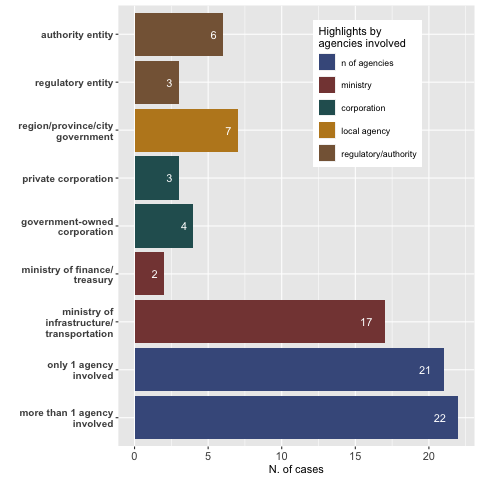

Figure 2: Key agencies involved

#### The administrative level of interventions

In Figure 3 we see the relevant administrative level(s) at which the described initiatives were implemented in the 43 examples considered:

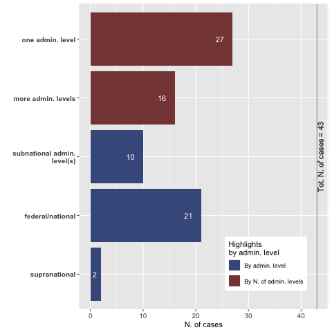

#### Year of launch

Figure 4 documents the time in which the submitted cases were launched: 69.8% of the cases were **launched in the last decade**, which is not surprising given the explicit request of the Presidency to submit recent cases.

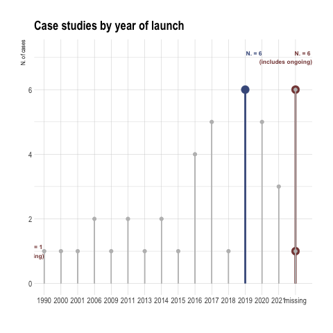

Figure 4: Year of launch of initiatives

#### Distributions by sector

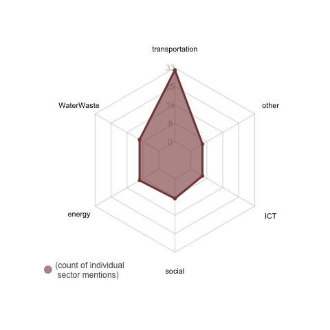

Figure 5: Distribution of cases by (individual) sector

#### Distribution by policy

In Figure 6 is is possible to see the distribution of cases across macro policy area (including when multiple areas were involved)

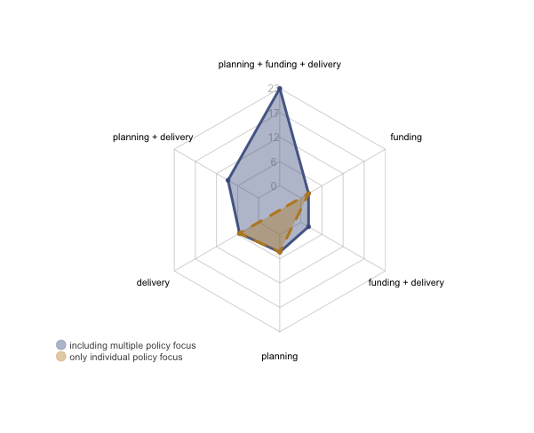

Figure 6: Distribution of cases by policy area